# Exploration

MYC

10/15/2021

First loading all the default settings and preliminary programs.

Path to Processed Data and loading

```r
data_location <- here::here("data","processed_data","processeddata.rds")
data<- readRDS(data_location)
```

View Summary of new Data, subsetted from the original raw data.

```r
str(data) #check structure of R object
```

```
## 'data.frame':    730 obs. of  32 variables:
##  $ SwollenLymphNodes: Factor w/ 2 levels "No","Yes": 2 2 2 2 2 1 1 1 2 1 ...
##  $ ChestCongestion  : Factor w/ 2 levels "No","Yes": 1 2 2 2 1 1 1 2 2 2 ...
##  $ ChillsSweats     : Factor w/ 2 levels "No","Yes": 1 1 2 2 2 2 2 2 2 1 ...
##  $ NasalCongestion  : Factor w/ 2 levels "No","Yes": 1 2 2 2 1 1 1 2 2 2 ...
##  $ CoughYN          : Factor w/ 2 levels "No","Yes": 2 2 1 2 1 2 2 2 2 2 ...
##  $ Sneeze           : Factor w/ 2 levels "No","Yes": 1 1 2 2 1 2 1 2 1 1 ...
##  $ Fatigue          : Factor w/ 2 levels "No","Yes": 2 2 2 2 2 2 2 2 2 2 ...
##  $ SubjectiveFever  : Factor w/ 2 levels "No","Yes": 2 2 2 2 2 2 2 2 2 1 ...
##  $ Headache         : Factor w/ 2 levels "No","Yes": 2 2 2 2 2 2 1 2 2 2 ...
##  $ Weakness         : Factor w/ 4 levels "None","Mild",..: 2 4 4 4 3 3 2 4 3 3 ...
##  $ WeaknessYN       : Factor w/ 2 levels "No","Yes": 2 2 2 2 2 2 2 2 2 2 ...
##  $ CoughIntensity   : Factor w/ 4 levels "None","Mild",..: 4 4 2 3 1 3 4 3 3 3 ...
##  $ CoughYN2         : Factor w/ 2 levels "No","Yes": 2 2 2 2 1 2 2 2 2 2 ...
##  $ Myalgia          : Factor w/ 4 levels "None","Mild",..: 2 4 4 4 2 3 2 4 3 2 ...
```

[output cut: 20 more lines]

```r
glimpse(data) #details of the data up to 4 levels, empty values = ""
```

```
## Rows: 730
## Columns: 32
## $ SwollenLymphNodes <fct> Yes, Yes, Yes, Yes, Yes, No, No, No, Yes, No, Yes, Y~
## $ ChestCongestion   <fct> No, Yes, Yes, Yes, No, No, No, Yes, Yes, Yes, Yes, Y~
## $ ChillsSweats      <fct> No, No, Yes, Yes, Yes, Yes, Yes, Yes, Yes, No, Yes, ~
## $ NasalCongestion   <fct> No, Yes, Yes, Yes, No, No, No, Yes, Yes, Yes, Yes, Y~
## $ CoughYN           <fct> Yes, Yes, No, Yes, No, Yes, Yes, Yes, Yes, Yes, No, ~
## $ Sneeze            <fct> No, No, Yes, Yes, No, Yes, No, Yes, No, No, No, No, ~
## $ Fatigue           <fct> Yes, Yes, Yes, Yes, Yes, Yes, Yes, Yes, Yes, Yes, Ye~
## $ SubjectiveFever   <fct> Yes, Yes, Yes, Yes, Yes, Yes, Yes, Yes, Yes, No, Yes~
## $ Headache          <fct> Yes, Yes, Yes, Yes, Yes, Yes, No, Yes, Yes, Yes, Yes~
## $ Weakness          <fct> Mild, Severe, Severe, Severe, Moderate, Moderate, Mi~
## $ WeaknessYN        <fct> Yes, Yes, Yes, Yes, Yes, Yes, Yes, Yes, Yes, Yes, Ye~
## $ CoughIntensity    <fct> Severe, Severe, Mild, Moderate, None, Moderate, Seve~
## $ CoughYN2          <fct> Yes, Yes, Yes, Yes, No, Yes, Yes, Yes, Yes, Yes, Yes~
```

[output cut: 19 more lines]

```r
summary(data)
```

```
##  SwollenLymphNodes ChestCongestion ChillsSweats NasalCongestion CoughYN
##  No :418           No :323         No :130      No :167         No : 75
##  Yes:312           Yes:407         Yes:600      Yes:563         Yes:655
##
##
##
##
##  Sneeze    Fatigue   SubjectiveFever Headache      Weakness   WeaknessYN
##  No :339   No : 64   No :230         No :115   None    : 49   No : 49
##  Yes:391   Yes:666   Yes:500         Yes:615   Mild    :223   Yes:681
##                                                Moderate:338
##                                                Severe  :120
##
##
##   CoughIntensity CoughYN2      Myalgia    MyalgiaYN RunnyNose AbPain
##  None    : 47    No : 47   None    : 79   No : 79   No :211   No :639
##  Mild    :154    Yes:683   Mild    :213   Yes:651   Yes:519   Yes: 91
##  Moderate:357              Moderate:325
##  Severe  :172              Severe  :113
##
##
##  ChestPain Diarrhea  EyePn     Insomnia  ItchyEye  Nausea    EarPn
##  No :497   No :631   No :617   No :315   No :551   No :475   No :568
##  Yes:233   Yes: 99   Yes:113   Yes:415   Yes:179   Yes:255   Yes:162
##
##
##
##
##  Hearing   Pharyngitis Breathless ToothPn   Vision    Vomit     Wheeze
##  No :700   No :119     No :436    No :565   No :711   No :652   No :510
##  Yes: 30   Yes:611     Yes:294    Yes:165   Yes: 19   Yes: 78   Yes:220
##
##
##
##
##     BodyTemp
##  Min.   : 97.20
##  1st Qu.: 98.20
##  Median : 98.50
##  Mean   : 98.94
##  3rd Qu.: 99.30
##  Max.   :103.10
```

Important variables: Outcome= Body temperature and our main categorical outcome is Nausea. We want to see if the other symptoms are correlated with (predict) those outcomes.

Limited selection of other symptoms (Selection of 5, based on vaugely off of the PeptoBismol jingle ):

1. Nausea
2. CoughYN
3. Pharyngitis
4. Vomit
5. Diarrhea

Reduce data to limited variables and BodyTemp. Preview to confirm

```r
SelectData<-data%>% #make into a new data frame
  #select limited variables and BodyTemp
  select(Nausea,
         CoughYN,
         Pharyngitis,
         Vomit,
         Diarrhea,
         BodyTemp)%>%
  #filter for only positive Nausea data, per instruction of prompt as it being the main categorical outcome
  filter(Nausea=="Yes")

summary(SelectData)
```

```
##  Nausea    CoughYN   Pharyngitis Vomit     Diarrhea     BodyTemp
##  No :  0   No : 29   No : 39     No :191   No :196   Min.   : 97.40
##  Yes:255   Yes:226   Yes:216     Yes: 64   Yes: 59   1st Qu.: 98.20
##                                                      Median : 98.60
##                                                      Mean   : 98.99
##                                                      3rd Qu.: 99.30
##                                                      Max.   :103.00
```

##Summary Table

```r
SelectData%>%
  #grouping by Nausea, the main categorical outcome
  group_by(Nausea,
           CoughYN,
           Pharyngitis,
           Vomit,
           Diarrhea)%>%
  #summarise the data, get observances and mean temp, calculate the standard deviation
  summarise(
    n=n(), #to count the number of observances
    mean=mean(BodyTemp),#calculate mean body temp
    sd=sd(BodyTemp) #calculate sd (Standard Deviation) of Body temp
  )%>%
  #arrange by highest number of n
  arrange(desc(n)) %>%
  print()
```

```
## # A tibble: 13 x 8
## # Groups:   Nausea, CoughYN, Pharyngitis, Vomit [8]
##    Nausea CoughYN Pharyngitis Vomit Diarrhea     n  mean     sd
##    <fct>  <fct>   <fct>       <fct> <fct>    <int> <dbl>  <dbl>
##  1 Yes    Yes     Yes         No    No         109  99.1  1.33
##  2 Yes    Yes     Yes         Yes   No          37  99.1  1.05
##  3 Yes    Yes     Yes         No    Yes         32  98.8  1.24
##  4 Yes    Yes     No          No    No          22  98.5  0.615
##  5 Yes    No      Yes         No    No          21  98.9  1.18
##  6 Yes    Yes     Yes         Yes   Yes         14  99.1  1.45
##  7 Yes    Yes     No          Yes   Yes          5  99.1  1.46
##  8 Yes    Yes     No          No    Yes          4  98.7  0.492
##  9 Yes    No      Yes         Yes   No           3  99.6  1.95
## 10 Yes    Yes     No          Yes   No           3  98.4  0.436
## 11 Yes    No      No          No    Yes          2  98.7  0
## 12 Yes    No      No          Yes   Yes          2  98.2  0.212
## 13 Yes    No      No          No    No           1  98.7 NA
```

Most cases with observed experience Nausea, Cough, Pharyngitis with a mean Body temperature of 99.1. Only once case where it was just Nausea and none of the other selected variables.

Save of temp and positive for nausea

```r
save_data_location <- here::here("data","processed_data","SelectData.rds")

saveRDS(SelectData, file = save_data_location)
```

Not satisfied with my version of summary table… so looking at other examples to see how to do this better. Found someone using this table1 program. Let’s see how it goes.

```r
library(table1)# saw this used in someone else's code, trying it out
table1(~   BodyTemp+
           CoughYN+
           Pharyngitis+
           Vomit+
         # the | splits it to be factor's col variables-- this case of Nausea-.
           Diarrhea | Nausea,
       #use prior data since selecteddata only shows the positive nausea hits
       data=data,
       overall="Total")
```

|  | No (N=475) | Yes (N=255) | Total (N=730) |
| --- | --- | --- | --- |
| BodyTemp |  |  |  |
| Mean (SD) | 98.9 (1.19) | 99.0 (1.21) | 98.9 (1.20) |
| Median [Min, Max] | 98.5 [97.2, 103] | 98.6 [97.4, 103] | 98.5 [97.2, 103] |
| CoughYN |  |  |  |
| No | 46 (9.7%) | 29 (11.4%) | 75 (10.3%) |
| Yes | 429 (90.3%) | 226 (88.6%) | 655 (89.7%) |
| Pharyngitis |  |  |  |
| No | 80 (16.8%) | 39 (15.3%) | 119 (16.3%) |
| Yes | 395 (83.2%) | 216 (84.7%) | 611 (83.7%) |
| Vomit |  |  |  |
| No | 461 (97.1%) | 191 (74.9%) | 652 (89.3%) |
| Yes | 14 (2.9%) | 64 (25.1%) | 78 (10.7%) |
| Diarrhea |  |  |  |
| No | 435 (91.6%) | 196 (76.9%) | 631 (86.4%) |
| Yes | 40 (8.4%) | 59 (23.1%) | 99 (13.6%) |

This is a very nice table, Need to look into about putting in BodyTemp as the factors in this and not just Nausea

##Histogram/Density plot

Code here is copy pasted and changes in the data source and fill aspects are based on the different comparisons.

By Nausea

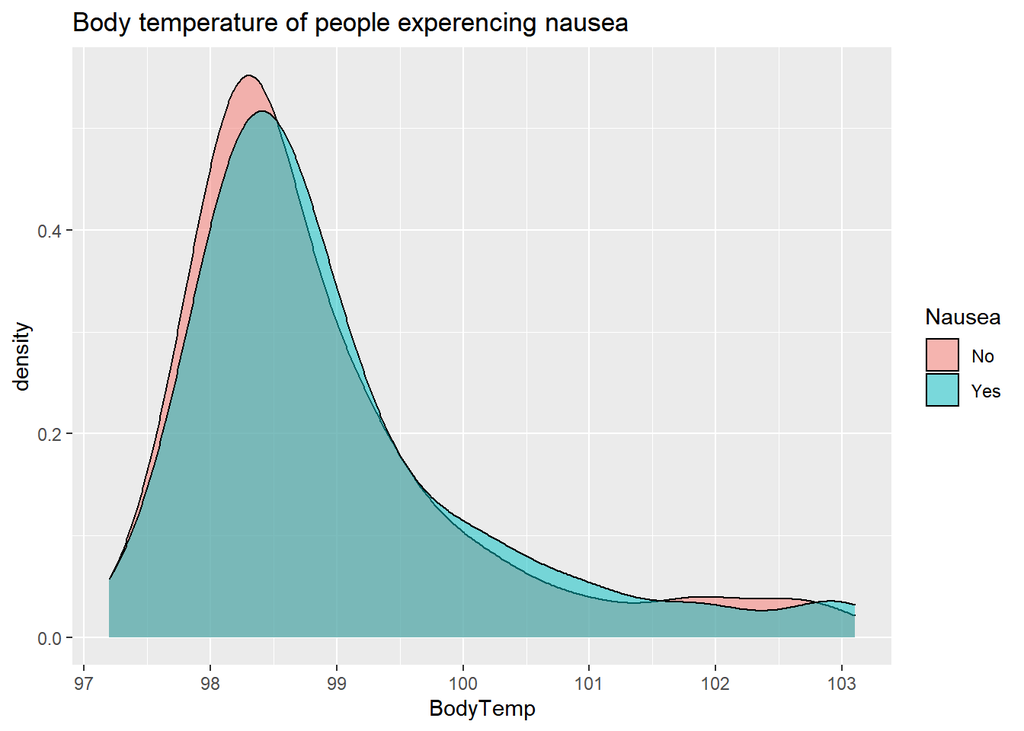

```r
data%>% #using original data to show Yes and No for Nausea
  ggplot(aes(x=BodyTemp, fill=Nausea)) +
    geom_density(adjust=1.5,
                 alpha=.5)+
  labs(title= "Body temperature of people experencing nausea")
```

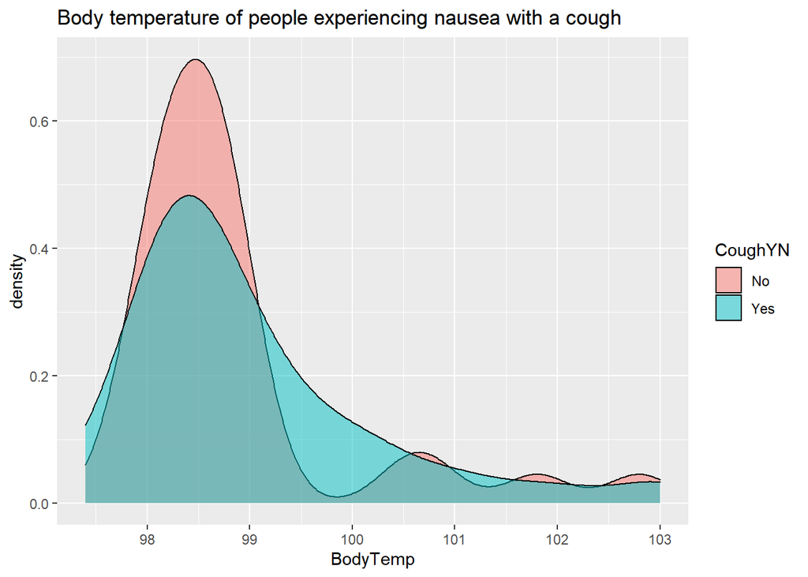

```r
SelectData%>%
  ggplot(aes(x=BodyTemp, fill=CoughYN)) +
    geom_density(adjust=1.5,
                 alpha=.5)+
    labs(title= "Body temperature of people experiencing nausea with a cough")
```

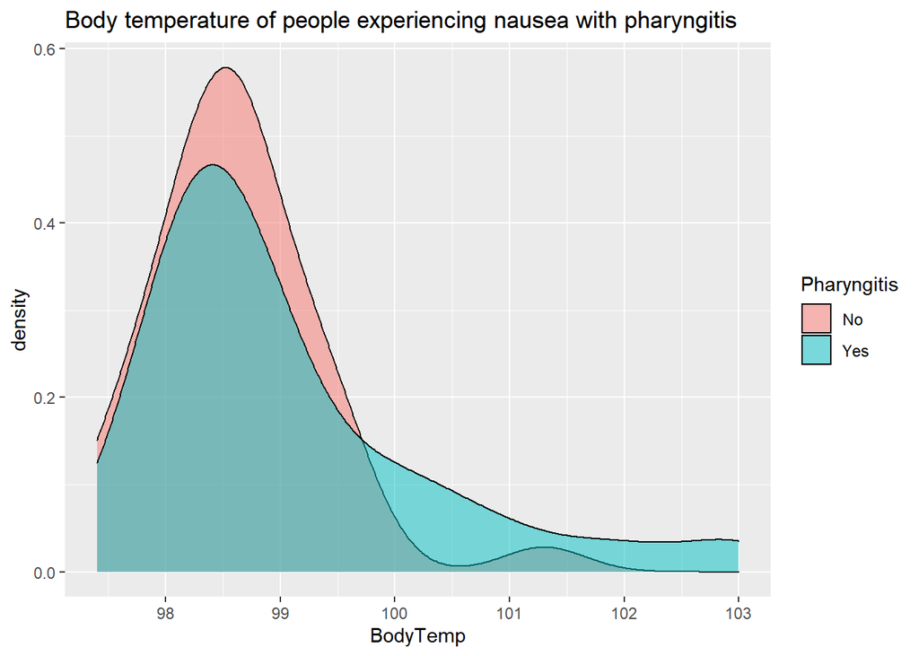

```r
SelectData%>%
  ggplot(aes(x=BodyTemp, fill=Pharyngitis)) +
    geom_density(adjust=1.5,
                 alpha=.5)+
    labs(title= "Body temperature of people experiencing nausea with pharyngitis")
```

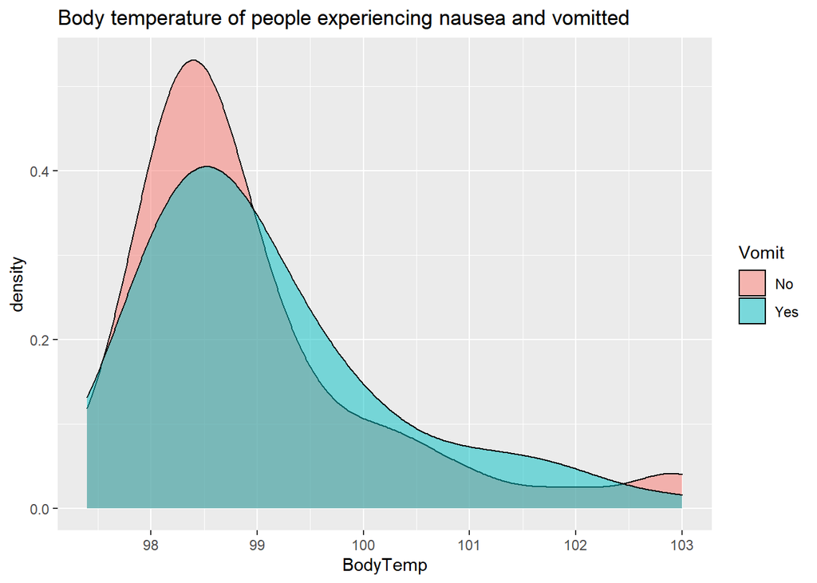

```r
SelectData%>%
  ggplot(aes(x=BodyTemp, fill=Vomit)) +
    geom_density(adjust=1.5,
                 alpha=.5)+
    labs(title= "Body temperature of people experiencing nausea and vomitted")
```

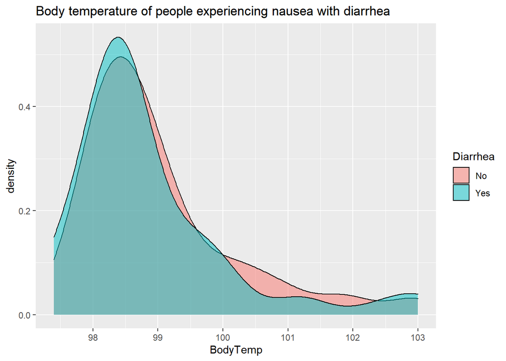

```r
SelectData%>%
  ggplot(aes(x=BodyTemp, fill=Diarrhea)) +
    geom_density(adjust=1.5,
                 alpha=.5)+
    labs(title= "Body temperature of people experiencing nausea with diarrhea")
```

##Scatterplots and Boxplots

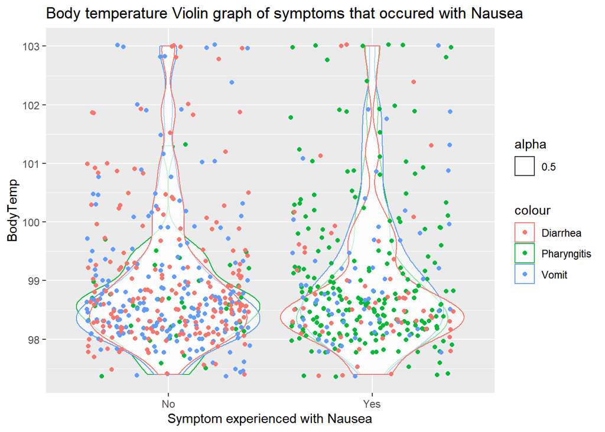

```r
#Nausea positive

SelectData%>% #only positive with Nausea
  ggplot(aes(y=BodyTemp))+
  geom_violin(aes(x=Pharyngitis, color="Pharyngitis", alpha=.5))+
  geom_violin(aes(x=Vomit, color="Vomit", alpha=.5))+
  geom_violin(aes(x=Diarrhea, color="Diarrhea", alpha=.5))+
  geom_jitter(aes(x=Pharyngitis, color="Pharyngitis"))+
  geom_jitter(aes(x=Vomit, color="Vomit"))+
  geom_jitter(aes(x=Diarrhea, color="Diarrhea"))+
  labs(title="Body temperature Violin graph of symptoms that occured with Nausea")+
  xlab("Symptom experienced with Nausea")
```

Need to reshape data to get the right output in ggplot I think I need to rotate the table to long form?

```r
#Pivot Select Data
PSData<-SelectData%>%
  group_by(CoughYN,
           Pharyngitis,
           Vomit,
           Diarrhea)%>%
  summarize(
    Temp=mean(BodyTemp),#calculate mean body temp
    sd=sd(BodyTemp))%>%
#really unsure if this was correct
  pivot_longer(
    cols = c(CoughYN, Pharyngitis,Vomit,Diarrhea),
    names_to = "Symptoms",
    values_to = "Presence" )
glimpse(PSData)
```

```
## Rows: 52
## Columns: 4
## $ Temp     <dbl> 98.70000, 98.70000, 98.70000, 98.70000, 98.70000, 98.70000, 9~
## $ sd       <dbl> NA, NA, NA, NA, 0.0000000, 0.0000000, 0.0000000, 0.0000000, 0~
## $ Symptoms <chr> "CoughYN", "Pharyngitis", "Vomit", "Diarrhea", "CoughYN", "Ph~
## $ Presence <fct> No, No, No, No, No, No, No, Yes, No, No, Yes, Yes, No, Yes, N~
```

Save Pivoted Data of mean temp and positive for nausea

```r
save_data_location <- here::here("data","processed_data","PivotSelect.rds")

saveRDS(PSData, file = save_data_location)
```

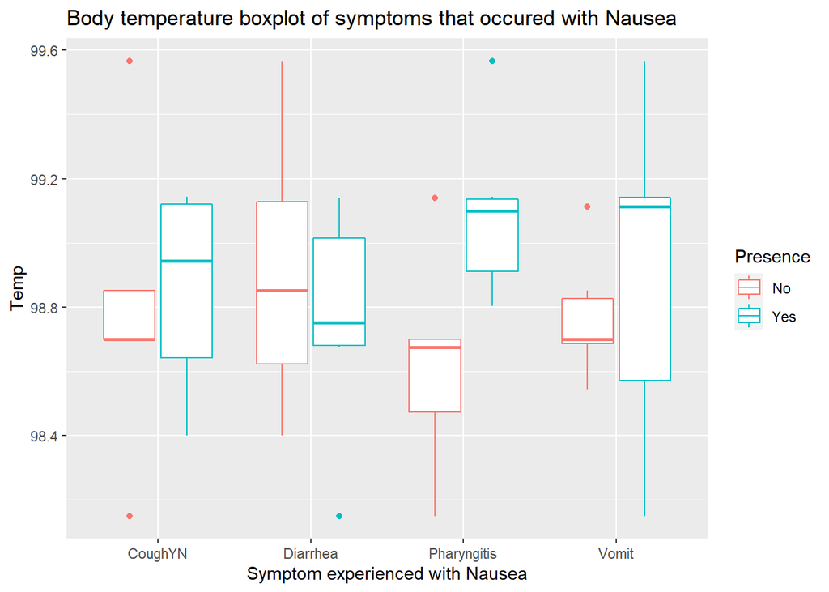

```r
PSData%>%
  ggplot(aes(x=Symptoms, y=Temp))+
  geom_boxplot(aes(color=Presence))+
  labs(title="Body temperature boxplot of symptoms that occured with Nausea")+
  xlab("Symptom experienced with Nausea")
```